# Google Playstore Data Analysis

Wahyu & Suryo

12/20/2020

# Analisis Data Google Playstore

# Pengantar

### Data yang digunakan

Dataset yang digunakan diambil dari: https://www.kaggle.com/ujjwalprakash/playstore

Dataset tersebut berisi daftar aplikasi pada Google Playstore beserta rinciannya. Terdapat total **10.840 baris** dan **13 kolom**.

Kolom-kolom pada dataset meliputi:

- **App**: Nama aplikasi
- **Category**: Kategori aplikasi
- **Rating**: Penilaian aplikasi (bintang 1 sampai 5)
- **Reviews**: Jumlah user reviews
- **Size**: Ukuran download (dalam Kilobyte)
- **Installs**: Jumlah installasi
- **Type**: Tipe pembayaran aplikasi (free atau paid)
- **Content Rating**: Penilaian kecocokan kedewasaan pengguna aplikasi

Ditambah 3 kolom yang tidak kami gunakan

- **Last Updated**: Tanggal update terakhir
- **Current Ver**: Versi aplikasi
- **Android ver**: Versi android

### Tujuan

Melihat banyaknya aplikasi yang ada di Google Playstore, kami ingin memodelkan suatu prediksi untuk menentukan popularitas aplikasi berdasarkan jumlah installasi menggunakan machine learning dengan algoritma klasifikasi **Naive Bayes**.

# Persiapan R

### Import libraries

```r
library(DT) #Untuk menampilkan tabel yang lebih enak dipandang
library(plyr) #Untuk membantu mempelajari data
library(dplyr) #Untuk membantu memanipulasi data
library(psych) #Untuk menampilkan koefisian korelasi
library(ggplot2) #Untuk membantu visualisasi data dengan plot
library(naivebayes) #Untuk algoritma Naive bayes
```

# Gambaran umum dataset

Import dataset lalu simpan ke data frame.

```r
gpData <- read.csv("playstore_analysis.csv")
df <- data.frame(gpData[1:10])
```

*Data frame diatas tidak meliputi 3 kolom terakhir karena kami rasa tidak relevan.*

Untuk selanjutnya akan terus menggunakan data frame. Data kemudian dapat Kami tampilkan dalam bentuk tabel. Di sini kami menggunakan datatable dari library DT agar tabel terlihat lebih rapi. Berikut tampilan sekilas beberapa baris data tersebut:

```r
datatable(head(df), options = list(autoWidth=TRUE, scrollX=300, searching=FALSE, paging=FALSE, info=FALSE))
```

|  | App | Category | Rating | Reviews | Size | Installs | Type | Price | Content.Rating | Genres |
| --- | --- | --- | --- | --- | --- | --- | --- | --- | --- | --- |
| 1 | Photo Editor &amp; Candy Camera &amp; Grid &amp; ScrapBook | ART_AND_DESIGN | 4.1 | 159 | 19000 | 10,000+ | Free | 0 | Everyone | Art &amp; Design |
| 2 | Coloring book moana | ART_AND_DESIGN | 3.9 | 967 | 14000 | 500,000+ | Free | 0 | Everyone | Art &amp; Design;Pretend Play |
| 3 | U Launcher Lite â€“ FREE Live Cool Themes, Hide Apps | ART_AND_DESIGN | 4.7 | 87510 | 8700 | 5,000,000+ | Free | 0 | Everyone | Art &amp; Design |
| 4 | Sketch - Draw &amp; Paint | ART_AND_DESIGN | 4.5 | 215644 | 25000 | 50,000,000+ | Free | 0 | Teen | Art &amp; Design |
| 5 | Pixel Draw - Number Art Coloring Book | ART_AND_DESIGN | 4.3 | 967 | 2800 | 100,000+ | Free | 0 | Everyone | Art &amp; Design;Creativity |
| 6 | Paper flowers instructions | ART_AND_DESIGN | 4.4 | 167 | 5600 | 50,000+ | Free | 0 | Everyone | Art &amp; Design |

Dari data tersebut dapat Kami lihat ringkasan kolom-kolom seperti berikut:

```r
summary(df)
```

```
##      App              Category             Rating         Reviews
##  Length:10840       Length:10840       Min.   :1.000   Min.   :       0
##  Class :character   Class :character   1st Qu.:4.000   1st Qu.:      38
##  Mode  :character   Mode  :character   Median :4.300   Median :    2094
##                                        Mean   :4.192   Mean   :  444153
##                                        3rd Qu.:4.500   3rd Qu.:   54776
##                                        Max.   :5.000   Max.   :78158306
##                                        NA's   :1474
##       Size            Installs             Type              Price
##  Min.   :     8.5   Length:10840       Length:10840       Length:10840
##  1st Qu.:  5900.0   Class :character   Class :character   Class :character
##  Median : 18000.0   Mode  :character   Mode  :character   Mode  :character
##  Mean   : 21516.5
##  3rd Qu.: 26000.0
##  Max.   :100000.0
##
##  Content.Rating        Genres
##  Length:10840       Length:10840
##  Class :character   Class :character
##  Mode  :character   Mode  :character
##
##
##
##
```

# Preprocessing

Pada kolom rating terdapat **1474** data yang hilang/kosong. Data kosong seperti ini dapat memengaruhi akurasi model sehingga kami memutuskan untuk menghapus baris yang mengandung data kosong.

```r
df <- na.omit(df)
summary(df)
```

```
##      App              Category             Rating         Reviews
##  Length:9366        Length:9366        Min.   :1.000   Min.   :       1
##  Class :character   Class :character   1st Qu.:4.000   1st Qu.:     186
##  Mode  :character   Mode  :character   Median :4.300   Median :    5930
##                                        Mean   :4.192   Mean   :  514050
##                                        3rd Qu.:4.500   3rd Qu.:   81533
##                                        Max.   :5.000   Max.   :78158306
##       Size            Installs             Type              Price
##  Min.   :     8.5   Length:9366        Length:9366        Length:9366
##  1st Qu.:  6600.0   Class :character   Class :character   Class :character
##  Median : 21000.0   Mode  :character   Mode  :character   Mode  :character
##  Mean   : 22705.7
##  3rd Qu.: 27000.0
##  Max.   :100000.0
##  Content.Rating        Genres
##  Length:9366        Length:9366
##  Class :character   Class :character
##  Mode  :character   Mode  :character
##
##
##
```

```r
unique(df$Installs)
```

```
##  [1] "10,000+"        "500,000+"       "5,000,000+"     "50,000,000+"
##  [5] "100,000+"       "50,000+"        "1,000,000+"     "10,000,000+"
##  [9] "5,000+"         "100,000,000+"   "1,000,000,000+" "1,000+"
## [13] "500,000,000+"   "100+"           "500+"           "10+"
## [17] "5+"             "50+"            "1+"
```

Kami lakukan proses ini di kolom baru bernama **Popularity**. Berikut proses duplikasi kolom **Installs** ke kolom **popularity** menggunakan fungsi **mutate** pada **dplyr**:

```r
df <- df %>% mutate(Popularity = Installs)
```

Untuk memulai proses binerisasi, perlu dilakukan konversi data dari char ke numerik. Pertama, kami hapus tanda **+** dan **,** untuk memudahkan konversi ke numerik.

```r
df[c("Popularity")] <- gsub('[+, ,]','',df$Popularity)
unique(df$Popularity)
```

```
##  [1] "10000"      "500000"     "5000000"    "50000000"   "100000"
##  [6] "50000"      "1000000"    "10000000"   "5000"       "100000000"
## [11] "1000000000" "1000"       "500000000"  "100"        "500"
## [16] "10"         "5"          "50"         "1"
```

```r
df[c("Popularity")] <- ifelse(as.numeric(df$Popularity) >= as.numeric(100000), "Popular", "Not Popular")
datatable(unique(cbind(df$Installs, df$Popularity)), colnames=c("Installs", "Popularity"),options = list(searching=FALSE, info=FALSE, paging=FALSE))
```

| Installs | Popularity |
| --- | --- |
| 10,000+ | Not Popular |
| 500,000+ | Popular |
| 5,000,000+ | Popular |
| 50,000,000+ | Popular |
| 100,000+ | Popular |
| 50,000+ | Not Popular |
| 1,000,000+ | Popular |
| 10,000,000+ | Popular |
| 5,000+ | Not Popular |
| 100,000,000+ | Popular |

[output cut: 9 more lines]

Selanjutnya, kami lakukan hapus juga tanda tanda **+** dan **,** pada kolom **Installs**

```r
df[c("Installs")] <- gsub('[+, ,]','',df$Installs)
unique(df$Installs)
```

```
##  [1] "10000"      "500000"     "5000000"    "50000000"   "100000"
##  [6] "50000"      "1000000"    "10000000"   "5000"       "100000000"
## [11] "1000000000" "1000"       "500000000"  "100"        "500"
## [16] "10"         "5"          "50"         "1"
```

Pada kolom **Price**, kami hapus tanda **$**

```r
df[c("Price")] <- gsub('[$]','',df$Price)
unique(df$Price)
```

```
##  [1] "0"      "4.99"   "3.99"   "6.99"   "7.99"   "5.99"   "2.99"   "3.49"
##  [9] "1.99"   "9.99"   "7.49"   "0.99"   "9.00"   "5.49"   "10.00"  "24.99"
## [17] "11.99"  "79.99"  "16.99"  "14.99"  "29.99"  "12.99"  "2.49"   "10.99"
## [25] "1.50"   "19.99"  "15.99"  "33.99"  "39.99"  "3.95"   "4.49"   "1.70"
## [33] "8.99"   "1.49"   "3.88"   "399.99" "17.99"  "400.00" "3.02"   "1.76"
## [41] "4.84"   "4.77"   "1.61"   "2.50"   "1.59"   "6.49"   "1.29"   "299.99"
## [49] "379.99" "37.99"  "18.99"  "389.99" "8.49"   "1.75"   "14.00"  "2.00"
## [57] "3.08"   "2.59"   "19.40"  "3.90"   "4.59"   "15.46"  "3.04"   "13.99"
## [65] "4.29"   "3.28"   "4.60"   "1.00"   "2.95"   "2.90"   "1.97"   "2.56"
## [73] "1.20"
```

Kami juga menerapkan proses binarisasi terhadap kolom Size, di mana aplikasi yang berukuran di atas **80.000 KB** dianggap **Large** dan di bawahnya dianggap **Small**.

```r
df[c("Size")] <- ifelse(df$Size >= as.numeric(80000), "Large", "Small")
```

Selanjutnya, kami melakukan pembelajaran data

```r
str(df)
```

```
## 'data.frame':    9366 obs. of  11 variables:
##  $ App           : chr  "Photo Editor & Candy Camera & Grid & ScrapBook" "Coloring book moana" "U Launcher Lite â\200“ FREE Live Cool Themes, Hide Apps" "Sketch - Draw & Paint" ...
##  $ Category      : chr  "ART_AND_DESIGN" "ART_AND_DESIGN" "ART_AND_DESIGN" "ART_AND_DESIGN" ...
##  $ Rating        : num  4.1 3.9 4.7 4.5 4.3 4.4 3.8 4.1 4.4 4.7 ...
##  $ Reviews       : int  159 967 87510 215644 967 167 178 36815 13791 121 ...
##  $ Size          : chr  "Small" "Small" "Small" "Small" ...
##  $ Installs      : chr  "10000" "500000" "5000000" "50000000" ...
##  $ Type          : chr  "Free" "Free" "Free" "Free" ...
##  $ Price         : chr  "0" "0" "0" "0" ...
##  $ Content.Rating: chr  "Everyone" "Everyone" "Everyone" "Teen" ...
##  $ Genres        : chr  "Art & Design" "Art & Design;Pretend Play" "Art & Design" "Art & Design" ...
##  $ Popularity    : chr  "Not Popular" "Popular" "Popular" "Popular" ...
##  - attr(*, "na.action")= 'omit' Named int [1:1474] 24 114 124 127 130 131 135 164 181 186 ...
##   ..- attr(*, "names")= chr [1:1474] "24" "114" "124" "127" ...
```

Kami mengkoreksi tipe-tipe variabel:

```r
df$Category <- as.factor(df$Category)
df$Rating <- as.numeric(df$Rating)
df$Reviews <- as.numeric(df$Reviews)
df$Size <- as.factor(df$Size)
df$Installs <- as.numeric(df$Installs)
df$Type <- as.factor(df$Type)
df$Price <- as.numeric(df$Price)
df$Content.Rating <- as.factor(df$Content.Rating)
df$Genres <- as.factor(df$Genres)
df$Popularity <- as.factor(df$Popularity)
str(df)
```

```
## 'data.frame':    9366 obs. of  11 variables:
##  $ App           : chr  "Photo Editor & Candy Camera & Grid & ScrapBook" "Coloring book moana" "U Launcher Lite â\200“ FREE Live Cool Themes, Hide Apps" "Sketch - Draw & Paint" ...
##  $ Category      : Factor w/ 33 levels "ART_AND_DESIGN",..: 1 1 1 1 1 1 1 1 1 1 ...
##  $ Rating        : num  4.1 3.9 4.7 4.5 4.3 4.4 3.8 4.1 4.4 4.7 ...
##  $ Reviews       : num  159 967 87510 215644 967 ...
##  $ Size          : Factor w/ 2 levels "Large","Small": 2 2 2 2 2 2 2 2 2 2 ...
##  $ Installs      : num  10000 500000 5000000 50000000 100000 50000 50000 1000000 1000000 10000 ...
##  $ Type          : Factor w/ 2 levels "Free","Paid": 1 1 1 1 1 1 1 1 1 1 ...
##  $ Price         : num  0 0 0 0 0 0 0 0 0 0 ...
##  $ Content.Rating: Factor w/ 6 levels "Adults only 18+",..: 2 2 2 5 2 2 2 2 2 2 ...
##  $ Genres        : Factor w/ 115 levels "Action","Action;Action & Adventure",..: 10 12 10 10 11 10 10 10 10 11 ...
##  $ Popularity    : Factor w/ 2 levels "Not Popular",..: 1 2 2 2 2 1 1 2 2 1 ...
##  - attr(*, "na.action")= 'omit' Named int [1:1474] 24 114 124 127 130 131 135 164 181 186 ...
##   ..- attr(*, "names")= chr [1:1474] "24" "114" "124" "127" ...
```

### Visualisasi data

Untuk mengembangkan model klasifikasi Naive Bayes, Kami perlu memastikan variabel-variabel independen tidak memiliki korelasi yang tinggi. Untuk kolom App tidak kami ikutkan. Di sini kami menggunakan library(psych).

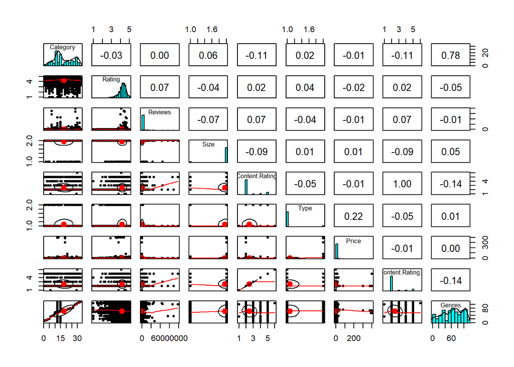

```r
pairs.panels(df[c("Category","Rating","Reviews", "Size", "Content.Rating", "Type", "Price", "Content.Rating", "Genres")])
```

Selanjutnya kami visualisasikan frekuensi popularitas menggunakan bar plot:

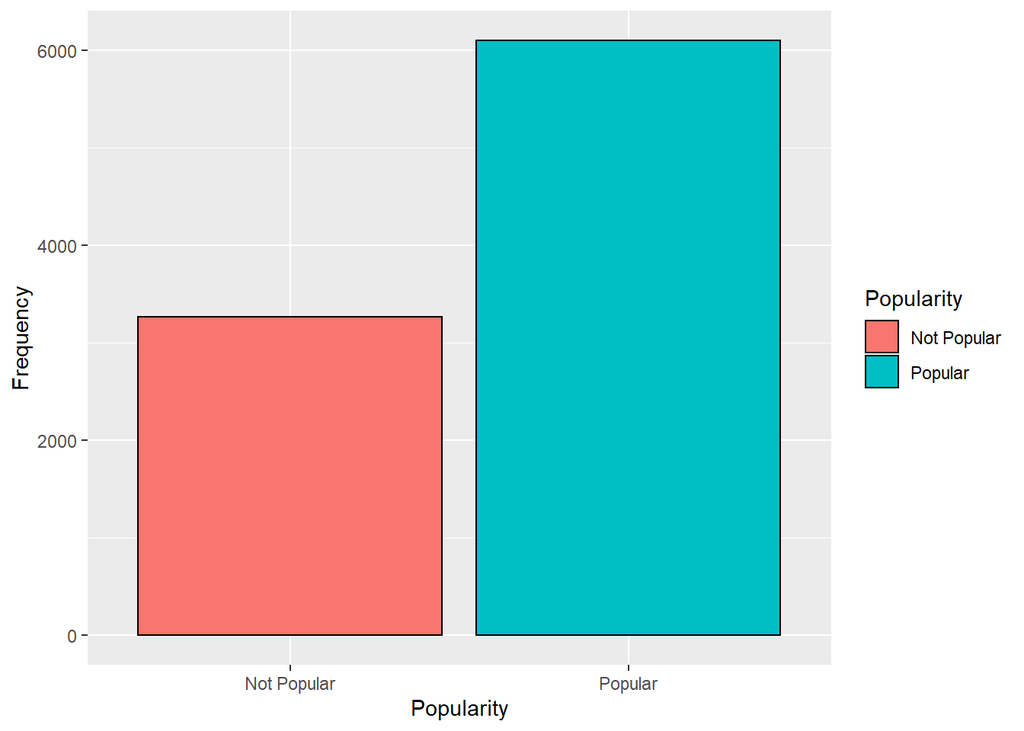

```r
ggplot(df, aes(x=Popularity, fill=Popularity)) +
  geom_bar(color="black",) +
  ylab("Frequency")
```

Terlihat lebih banyak aplikasi yang populer dari pada yang tidak populer.

# Partisi Data

Kami akan mempartisi data menjadi training set dan testing set dengan porsi **80%** training dan **20%** testing. Dengan memberi lebih banyak data untuk melatih model diharapkan dapat meningkatkan akurasi dan menghindari underfitting atau overfitting.

Berikut proses partisi data:

```r
set.seed(2020) #Menetapkan seed agar dapat digunakan kembali
sampling <- sample(2, nrow(df), replace = TRUE, prob = c(0.8, 0.2))

trainSet <- df[sampling == 1,]
testSet <- df[sampling == 2,]

datatable(cbind(nrow(trainSet), nrow(testSet)),colnames=c("Training Set","Testing Set"), options = list(searching=FALSE, info=FALSE, paging=FALSE))
```

| Training Set | Testing Set |
| --- | --- |
| 7542 | 1824 |

# Pemodelan Naive Bayes

Kami memasukkan data pada **Training Set** dan **Testing Set** ke model naive bayes. Ternyata terdapat **zero-probabilities**. Hal ini dapat diatasi dengan menggunakan **Laplace Smoothing**. Kami juga menggunakan **Kernel Density Estimation** untuk mengurangi tingkat misklasifikasi.

### Training:

```r
trainModel <- naive_bayes(Popularity ~ ., data = c(trainSet[2:5], trainSet[7:11]), laplace = 1, usekernel = TRUE)
trainModel
```

```
##
## ================================== Naive Bayes ==================================
##
##  Call:
## naive_bayes.formula(formula = Popularity ~ ., data = c(trainSet[2:5],
##     trainSet[7:11]), laplace = 1, usekernel = TRUE)
##
## ---------------------------------------------------------------------------------
##
## Laplace smoothing: 1
##
## ---------------------------------------------------------------------------------
##
##  A priori probabilities:
##
## Not Popular     Popular
##   0.3476531   0.6523469
##
## ---------------------------------------------------------------------------------
##
##  Tables:
##
## ---------------------------------------------------------------------------------
##  ::: Category (Categorical)
## ---------------------------------------------------------------------------------
##
## Category              Not Popular     Popular
##   ART_AND_DESIGN      0.007156309 0.006460731
##   AUTO_AND_VEHICLES   0.009039548 0.008479709
##   BEAUTY              0.005649718 0.003836059
##   BOOKS_AND_REFERENCE 0.025988701 0.015748031
##   BUSINESS            0.048587571 0.022410660
##   COMICS              0.008662900 0.006662629
##   COMMUNICATION       0.025988701 0.039773874
##   DATING              0.020715631 0.019785988
##   EDUCATION           0.004143126 0.023420149
##   ENTERTAINMENT       0.001129944 0.025035332
##   EVENTS              0.009416196 0.002624672
##   FAMILY              0.219209040 0.167171411
##   FINANCE             0.045951036 0.028063800
```

[output cut: 95 more lines]

```
##   Small  0.98399390 0.95367737
##
## ---------------------------------------------------------------------------------
##  ::: Type (Bernoulli)
## ---------------------------------------------------------------------------------
##
## Type   Not Popular    Popular
##   Free  0.83917683 0.97887038
##   Paid  0.16082317 0.02112962
##
## ---------------------------------------------------------------------------------
##
## # ... and 3 more tables
##
## ---------------------------------------------------------------------------------
```

Berikut tampilan keseluruhan tabelnya:

```r
tables(trainModel, which = NULL)
```

```
##
## ---------------------------------------------------------------------------------
##  ::: Category (Categorical)
## ---------------------------------------------------------------------------------
##
## Category              Not Popular     Popular
##   ART_AND_DESIGN      0.007156309 0.006460731
##   AUTO_AND_VEHICLES   0.009039548 0.008479709
##   BEAUTY              0.005649718 0.003836059
##   BOOKS_AND_REFERENCE 0.025988701 0.015748031
##   BUSINESS            0.048587571 0.022410660
##   COMICS              0.008662900 0.006662629
##   COMMUNICATION       0.025988701 0.039773874
##   DATING              0.020715631 0.019785988
##   EDUCATION           0.004143126 0.023420149
##   ENTERTAINMENT       0.001129944 0.025035332
##   EVENTS              0.009416196 0.002624672
##   FAMILY              0.219209040 0.167171411
##   FINANCE             0.045951036 0.028063800
##   FOOD_AND_DRINK      0.006403013 0.014738542
##   GAME                0.058380414 0.147183525
##   HEALTH_AND_FITNESS  0.021468927 0.036139713
##   HOUSE_AND_HOME      0.004143126 0.011104381
##   LIBRARIES_AND_DEMO  0.011299435 0.005451242
##   LIFESTYLE           0.048210923 0.025237230
##   MAPS_AND_NAVIGATION 0.016572505 0.012921462
##   MEDICAL             0.076836158 0.015748031
##   NEWS_AND_MAGAZINES  0.026365348 0.022410660
##   PARENTING           0.005649718 0.005249344
##   PERSONALIZATION     0.046704331 0.028669493
##   PHOTOGRAPHY         0.017702448 0.042398546
##   PRODUCTIVITY        0.031638418 0.040783364
##   SHOPPING            0.011299435 0.032505552
##   SOCIAL              0.019585687 0.030890369
##   SPORTS              0.026365348 0.037552998
##   TOOLS               0.100564972 0.065213002
##   TRAVEL_AND_LOCAL    0.021468927 0.026246719
##   VIDEO_PLAYERS       0.014689266 0.018978397
##   WEATHER             0.003013183 0.011104381
##
```

[output cut: 237 more lines]

```
##   Strategy;Action & Adventure           0.0003653635 0.0001986097
##   Strategy;Creativity                   0.0003653635 0.0003972195
##   Strategy;Education                    0.0003653635 0.0003972195
##   Tools                                 0.0975520643 0.0639523337
##   Tools;Education                       0.0003653635 0.0003972195
##   Travel & Local                        0.0208257216 0.0256206554
##   Travel & Local;Action & Adventure     0.0003653635 0.0003972195
##   Trivia                                0.0043843624 0.0023833168
##   Video Players & Editors               0.0142491779 0.0182720953
##   Video Players & Editors;Creativity    0.0003653635 0.0003972195
##   Video Players & Editors;Music & Video 0.0003653635 0.0007944389
##   Weather                               0.0029229083 0.0109235353
##   Word                                  0.0018268177 0.0041708044
##
## ---------------------------------------------------------------------------------
```

### Testing:

```r
testModel <- naive_bayes(Popularity ~ ., data = c(testSet[2:5], testSet[7:11]), laplace = 1, usekernel = TRUE)
testModel
```

```
##
## ================================== Naive Bayes ==================================
##
##  Call:
## naive_bayes.formula(formula = Popularity ~ ., data = c(testSet[2:5],
##     testSet[7:11]), laplace = 1, usekernel = TRUE)
##
## ---------------------------------------------------------------------------------
##
## Laplace smoothing: 1
##
## ---------------------------------------------------------------------------------
##
##  A priori probabilities:
##
## Not Popular     Popular
##   0.3547149   0.6452851
##
## ---------------------------------------------------------------------------------
##
##  Tables:
##
## ---------------------------------------------------------------------------------
##  ::: Category (Categorical)
## ---------------------------------------------------------------------------------
##
## Category              Not Popular     Popular
##   ART_AND_DESIGN      0.011764706 0.005785124
##   AUTO_AND_VEHICLES   0.007352941 0.004958678
##   BEAUTY              0.010294118 0.004132231
##   BOOKS_AND_REFERENCE 0.020588235 0.017355372
##   BUSINESS            0.045588235 0.029752066
##   COMICS              0.004411765 0.002479339
##   COMMUNICATION       0.030882353 0.037190083
##   DATING              0.030882353 0.020661157
##   EDUCATION           0.005882353 0.023140496
##   ENTERTAINMENT       0.001470588 0.020661157
##   EVENTS              0.004411765 0.006611570
##   FAMILY              0.226470588 0.154545455
##   FINANCE             0.054411765 0.023966942
```

[output cut: 95 more lines]

```
##   Small 0.990755008 0.951653944
##
## ---------------------------------------------------------------------------------
##  ::: Type (Bernoulli)
## ---------------------------------------------------------------------------------
##
## Type   Not Popular    Popular
##   Free  0.84899846 0.97709924
##   Paid  0.15100154 0.02290076
##
## ---------------------------------------------------------------------------------
##
## # ... and 3 more tables
##
## ---------------------------------------------------------------------------------
```

Berikut tampilan keseluruhan tabelnya:

```r
tables(testModel, which = NULL)
```

```
##
## ---------------------------------------------------------------------------------
##  ::: Category (Categorical)
## ---------------------------------------------------------------------------------
##
## Category              Not Popular     Popular
##   ART_AND_DESIGN      0.011764706 0.005785124
##   AUTO_AND_VEHICLES   0.007352941 0.004958678
##   BEAUTY              0.010294118 0.004132231
##   BOOKS_AND_REFERENCE 0.020588235 0.017355372
##   BUSINESS            0.045588235 0.029752066
##   COMICS              0.004411765 0.002479339
##   COMMUNICATION       0.030882353 0.037190083
##   DATING              0.030882353 0.020661157
##   EDUCATION           0.005882353 0.023140496
##   ENTERTAINMENT       0.001470588 0.020661157
##   EVENTS              0.004411765 0.006611570
##   FAMILY              0.226470588 0.154545455
##   FINANCE             0.054411765 0.023966942
##   FOOD_AND_DRINK      0.007352941 0.014876033
##   GAME                0.048529412 0.152066116
##   HEALTH_AND_FITNESS  0.027941176 0.038016529
##   HOUSE_AND_HOME      0.001470588 0.010743802
##   LIBRARIES_AND_DEMO  0.010294118 0.004132231
##   LIFESTYLE           0.052941176 0.023966942
##   MAPS_AND_NAVIGATION 0.008823529 0.011570248
##   MEDICAL             0.079411765 0.014876033
##   NEWS_AND_MAGAZINES  0.027941176 0.030578512
##   PARENTING           0.008823529 0.005785124
##   PERSONALIZATION     0.030882353 0.025619835
##   PHOTOGRAPHY         0.016176471 0.043801653
##   PRODUCTIVITY        0.033823529 0.038016529
##   SHOPPING            0.011764706 0.035537190
##   SOCIAL              0.026470588 0.033057851
##   SPORTS              0.030882353 0.038016529
##   TOOLS               0.083823529 0.075206612
##   TRAVEL_AND_LOCAL    0.019117647 0.024793388
##   VIDEO_PLAYERS       0.016176471 0.016528926
##   WEATHER             0.002941176 0.011570248
##
```

[output cut: 237 more lines]

```
##   Strategy;Action & Adventure           0.0013123360 0.0023219814
##   Strategy;Creativity                   0.0013123360 0.0007739938
##   Strategy;Education                    0.0013123360 0.0007739938
##   Tools                                 0.0748031496 0.0704334365
##   Tools;Education                       0.0013123360 0.0007739938
##   Travel & Local                        0.0170603675 0.0232198142
##   Travel & Local;Action & Adventure     0.0013123360 0.0007739938
##   Trivia                                0.0039370079 0.0038699690
##   Video Players & Editors               0.0144356955 0.0154798762
##   Video Players & Editors;Creativity    0.0013123360 0.0015479876
##   Video Players & Editors;Music & Video 0.0013123360 0.0007739938
##   Weather                               0.0026246719 0.0108359133
##   Word                                  0.0039370079 0.0023219814
##
## ---------------------------------------------------------------------------------
```

# Prediksi

Misal kami ingin memprediksi suatu aplikasi dengan keterangan sebagai berikut:

- Category: Tools
- Rating: 4.1
- Reviews: 200
- Size: Small
- Type: Free
- Price: 0
- Content.Rating: Everyone
- Genres: Shopping

```r
inputSet <- data.frame(Category = "Tools", Rating = 4.1, Reviews = 200, Size = "Small", Type = "Free", Price = 0, Content.Rating = "Everyone", Genres ="Shopping")
```

```r
options(scipen=0) #Mengaktifkan notasi ilmiah
names(inputSet) <- names(trainModel) #Memastikan kesamaan nama kolom
trainPrediction <- predict(trainModel, inputSet, type="prob")
trainPrediction
```

```
##      Not Popular   Popular
## [1,]   0.3476531 0.6523469
```

Aplikasi yang kami inputkan memiliki probabilitas **65%** menjadi populer dan **34%** tidak populer.

Kami lakukan juga prediksi pada model testing.

```r
names(inputSet) <- names(testModel) #Memastikan kesamaan nama kolom
testPrediction <- predict(testModel, inputSet, type="prob")
testPrediction
```

```
##      Not Popular   Popular
## [1,]   0.3547149 0.6452851
```

Kali ini probabilitas populer **64%** dan tidak populer **35%**.

# Confusion Matrix

Untuk mengecek akurasi, kami menggunakan **Confusion Matrix**.

```r
trainPrediction1 <- predict(trainModel, trainSet)
trainConfusionMatrix <- table(trainPrediction1, trainSet$Popularity)
trainConfusionMatrix
```

```
##
## trainPrediction1 Not Popular Popular
##      Not Popular        2543     576
##      Popular              79    4344
```

Dapat dilihat pada confusion matrix di atas bahwa model berhasil memprediksi **2543** aplikasi yang tidak populer dan **4344** aplikasi populer dengan benar. Dengan menggunakan confusion matrix di atas kita dapat menghitung akurasi dengan membagi sum diagonal dengan sum keseluruhan.

```r
trainAccuracy <- sum(diag(trainConfusionMatrix)) / sum(trainConfusionMatrix)
trainAccuracy
```

```
## [1] 0.913153
```

Didapat akurasi training **91%**.

Lakukan cara serupa untuk menghitung akurasi testing.

```r
testPrediction1 <- predict(testModel, testSet)
testConfusionMatrix <- table(testPrediction1, testSet$Popularity)
testConfusionMatrix
```

```
##
## testPrediction1 Not Popular Popular
##     Not Popular         578      63
##     Popular              69    1114
```

Berhasil memprediksi **578** tidak populer dan **1114** populer dengan benar.

```r
testAccuracy <- sum(diag(testConfusionMatrix)) / sum(testConfusionMatrix)
testAccuracy
```

```
## [1] 0.9276316
```

Didapat akurasi testing **92%**

Tidak ditemukan indikasi overfitting atau underfitting, serta prediksi yang dikeluarkan masuk akal.

# Kesimpulan